# ABAxCOV Rev 9-23-22

Cassin Gonzales

9/23/2022

## Load Data

```r
library(here)
```

```r
library(sjPlot)
library(tidyverse)
library(haven)
library(lme4)
library(lmerTest)
library(MuMIn)
library(sjPlot)
library(emmeans)
library(modelsummary)
library(glmmTMB)
library(interactions)
library(rstatix)
library(r2mlm)
library(broom.mixed)
theme_set(theme_bw())
```

```r
abacov <- read_sav(here("data_files","ABAxCOV 2022","Abacov4_long.sav"))
```

```r
rmarkdown::paged_table(abacov)
```

| ID | PIN | Site | Sex | Race | RaceTri | Age | PrimPay3 | PrimPay25 | Hours | Tele | Time | Season | Phase | Phase1 | Phase2 | Phase3 | dumPhase1 | dumPhase2 | dumPhase3 |
| --- | --- | --- | --- | --- | --- | --- | --- | --- | --- | --- | --- | --- | --- | --- | --- | --- | --- | --- | --- |
| 1 | 141659 | 0 | 0 | 1 | 1 | 9 | 0 | 0 | 53.000000 | 0 | 0 | 0 | 1 | 0 | 0 | 0 | 1 | 0 | 0 |
| 1 | 141659 | 0 | 0 | 1 | 1 | 9 | 0 | 0 | 28.500000 | 0 | 1 | 0 | 1 | 1 | 0 | 0 | 1 | 0 | 0 |
| 1 | 141659 | 0 | 0 | 1 | 1 | 9 | 0 | 0 | 31.750000 | 0 | 2 | 0 | 1 | 2 | 0 | 0 | 1 | 0 | 0 |
| 1 | 141659 | 0 | 0 | 1 | 1 | 9 | 0 | 0 | 45.283330 | 0 | 3 | 1 | 1 | 3 | 0 | 0 | 1 | 0 | 0 |
| 1 | 141659 | 0 | 0 | 1 | 1 | 9 | 0 | 0 | 150.583300 | 0 | 4 | 1 | 1 | 4 | 0 | 0 | 1 | 0 | 0 |
| 1 | 141659 | 0 | 0 | 1 | 1 | 9 | 0 | 0 | 94.300000 | 0 | 5 | 1 | 1 | 5 | 0 | 0 | 1 | 0 | 0 |
| 1 | 141659 | 0 | 0 | 1 | 1 | 9 | 0 | 0 | 37.666670 | 0 | 6 | 0 | 1 | 6 | 0 | 0 | 1 | 0 | 0 |
| 1 | 141659 | 0 | 0 | 1 | 1 | 9 | 0 | 0 | 36.700000 | 0 | 7 | 0 | 1 | 7 | 0 | 0 | 1 | 0 | 0 |
| 1 | 141659 | 0 | 0 | 1 | 1 | 9 | 0 | 0 | 32.750000 | 0 | 8 | 1 | 1 | 8 | 0 | 0 | 1 | 0 | 0 |
| 1 | 141659 | 0 | 0 | 1 | 1 | 9 | 0 | 0 | 31.416660 | 0 | 9 | 1 | 1 | 9 | 0 | 0 | 1 | 0 | 0 |

[output cut: 6782 more lines]

```r
abacov$Site <- as.factor(abacov$Site)
abacov$Sex <- as.factor(abacov$Sex)
abacov$Race <- as.factor(abacov$Race)
abacov$RaceTri <- as.factor(abacov$RaceTri)
abacov$Age <- as.numeric(abacov$Age)
abacov$PrimPay3 <- as.factor(abacov$PrimPay3)
abacov$PrimPay25 <- as.factor(abacov$PrimPay25)
abacov$Tele <- as.factor(abacov$Tele)
```

## Explore Data

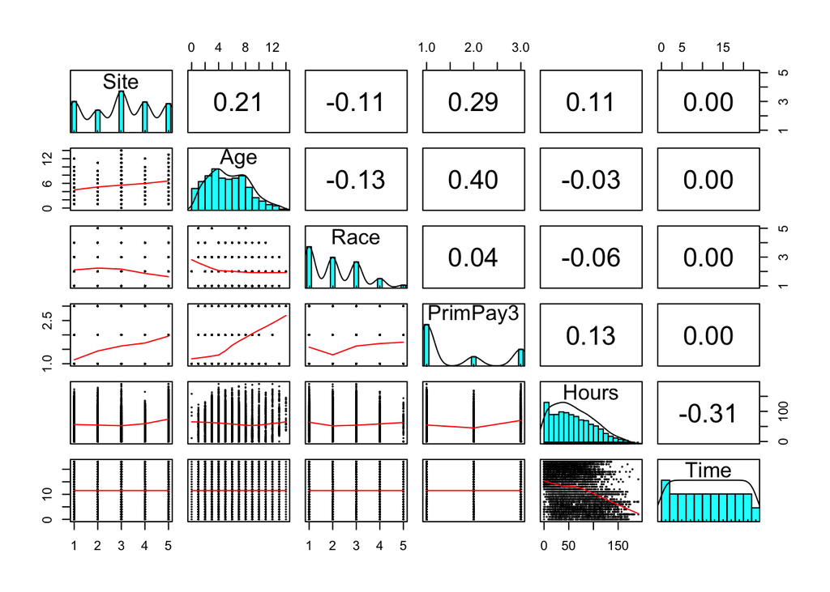

```r
abacov %>%
    select(Site, Age, Race, PrimPay3, Hours, Time) %>%
    psych::pairs.panels(ellipses = FALSE, cex = 0.2, cex.cor = 1)
```

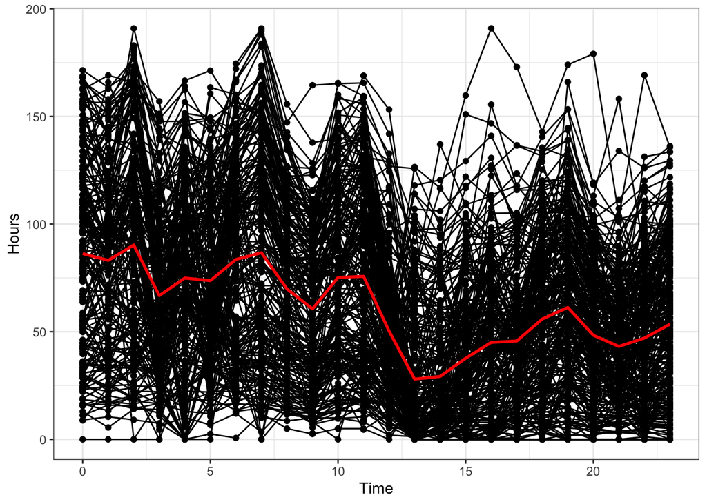

```r
p1 <- ggplot(abacov, aes(x = Time, y = Hours)) +
  geom_point() +
  geom_line(aes(group = ID)) +  # add lines to connect the data for each person
  # add a mean trajectory
  stat_summary(fun = "mean", col = "red", size = 1, geom = "line")
p1
```

```r
abacov %>%
  get_summary_stats(Hours, type = "mean_sd")
```

```
## # A tibble: 1 × 4
##   variable     n  mean    sd
##   <chr>    <dbl> <dbl> <dbl>
## 1 Hours     5490  59.9  41.8
```

```r
abacov %>%
  group_by(PrimPay3) %>%
  get_summary_stats(Hours, type = "mean_sd")
```

```
## # A tibble: 3 × 5
##   PrimPay3 variable     n  mean    sd
##   <fct>    <chr>    <dbl> <dbl> <dbl>
## 1 0        Hours     3228  57.2  39.3
## 2 1        Hours      727  48.1  36.4
## 3 2        Hours     1535  71.2  46.5
```

```r
abacov %>%
  group_by(RaceTri) %>%
  get_summary_stats(Hours, type = "mean_sd")
```

```
## # A tibble: 4 × 5
##   RaceTri variable     n  mean    sd
##   <fct>   <chr>    <dbl> <dbl> <dbl>
## 1 0       Hours     1730  65.8  42.4
## 2 1       Hours     1228  54.6  38.9
## 3 2       Hours     1528  58.9  42.3
## 4 <NA>    Hours     1004  57.8  42.2
```

```r
abacov %>%
  group_by(Phase) %>%
  get_summary_stats(Hours, type = "mean_sd")
```

```
## # A tibble: 3 × 5
##   Phase variable     n  mean    sd
##   <dbl> <chr>    <dbl> <dbl> <dbl>
## 1     1 Hours     2482  76.9  43.1
## 2     2 Hours      684  35.9  33.1
## 3     3 Hours     2324  48.8  34.8
```

```r
abacov %>%
  group_by(Phase, PrimPay3) %>%
  get_summary_stats(Hours, type = "mean_sd")
```

```
## # A tibble: 9 × 6
##   PrimPay3 Phase variable     n  mean    sd
##   <fct>    <dbl> <chr>    <dbl> <dbl> <dbl>
## 1 0            1 Hours     1431  69.0  40.1
## 2 1            1 Hours      315  62.1  41.0
## 3 2            1 Hours      736  98.7  41.7
## 4 0            2 Hours      400  37.6  33.4
## 5 1            2 Hours       89  31.3  29.7
## 6 2            2 Hours      195  34.7  33.7
## 7 0            3 Hours     1397  50.8  36.2
## 8 1            3 Hours      323  39.0  27.4
## 9 2            3 Hours      604  49.4  34.3
```

```r
abacov %>%
  group_by(Phase, RaceTri) %>%
  get_summary_stats(Hours, type = "mean_sd")
```

```
## # A tibble: 12 × 6
##    RaceTri Phase variable     n  mean    sd
##    <fct>   <dbl> <chr>    <dbl> <dbl> <dbl>
##  1 0           1 Hours      820  83.0  41.8
##  2 1           1 Hours      566  68.2  42.5
##  3 2           1 Hours      703  78.0  44.0
##  4 <NA>        1 Hours      393  74.9  43.2
##  5 0           2 Hours      210  37.4  34.6
##  6 1           2 Hours      152  38.1  32.8
##  7 2           2 Hours      194  34.0  30.4
##  8 <NA>        2 Hours      128  34.0  34.7
##  9 0           3 Hours      700  54.2  36.2
## 10 1           3 Hours      510  44.5  30.7
## 11 2           3 Hours      631  45.3  33.2
## 12 <NA>        3 Hours      483  50.1  37.7
```

## Unconditional Model

```r
ran_int <- lmer(Hours ~ 1 + (1 | ID), data = abacov)

summary(ran_int)
```

```
## Linear mixed model fit by REML. t-tests use Satterthwaite's method [
## lmerModLmerTest]
## Formula: Hours ~ 1 + (1 | ID)
##    Data: abacov
##
## REML criterion at convergence: 54565.7
##
## Scaled residuals:
##     Min      1Q  Median      3Q     Max
## -3.0316 -0.6028 -0.0510  0.5951  3.8754
##
## Random effects:
##  Groups   Name        Variance Std.Dev.
##  ID       (Intercept)  643.1   25.36
##  Residual             1072.1   32.74
## Number of obs: 5490, groups:  ID, 283
##
## Fixed effects:
##             Estimate Std. Error     df t value Pr(>|t|)
## (Intercept)    58.47       1.60 284.35   36.53   <2e-16 ***
## ---
## Signif. codes:  0 '***' 0.001 '**' 0.01 '*' 0.05 '.' 0.1 ' ' 1
```

fixed effect: Y00 is 58.47. The estimated grand mean of hours for all participants is 58.47

random effect: Uij = 643.1 is the deviation between jth individual and the grand mean. Eij = 1072.1 this is the deviation of the ith timepoint from the mean hours received by a child.

### ICC calculation

```r
643.1/(643.1 + 1072.1)
```

```
## [1] 0.3749417
```

The proportation of the variance in hours of therapy utillization that is due to between participant differences is .375.

### Design Effect

Design effect = 1 + (average cluster size - 1) x ICC

```r
mean(table(abacov$ID))
```

```
## [1] 24
```

mean cluster size = 24

```r
1 + 23*.375
```

```
## [1] 9.625
```

design effect = 9.625

## Hypothesis Testing

```r
m_phase <- glmmTMB(Hours ~ Phase1 + Phase2 + Phase3 + (Phase1 + Phase2 + Phase3 | ID), data = abacov, REML = TRUE)
summary(m_phase)
```

```
##  Family: gaussian  ( identity )
## Formula:
## Hours ~ Phase1 + Phase2 + Phase3 + (Phase1 + Phase2 + Phase3 |      ID)
## Data: abacov
##
##      AIC      BIC   logLik deviance df.resid
##  51414.8  51513.9 -25692.4  51384.8     5479
##
## Random effects:
##
## Conditional model:
##  Groups   Name        Variance Std.Dev. Corr
##  ID       (Intercept) 1435.65  37.890
##           Phase1        10.31   3.210   -0.48
##           Phase2       224.27  14.976   -0.33 -0.43
##           Phase3        16.58   4.071    0.23  0.15 -0.66
##  Residual              464.40  21.550
## Number of obs: 5490, groups:  ID, 283
##
## Dispersion estimate for gaussian family (sigma^2):  464
##
## Conditional model:
##             Estimate Std. Error z value Pr(>|z|)
## (Intercept)  82.5305     2.6927  30.650  < 2e-16 ***
## Phase1       -1.4416     0.2531  -5.696 1.23e-08 ***
## Phase2      -10.8286     1.0400 -10.412  < 2e-16 ***
## Phase3        2.3555     0.2904   8.112 4.98e-16 ***
## ---
## Signif. codes:  0 '***' 0.001 '**' 0.01 '*' 0.05 '.' 0.1 ' ' 1
```

During phase 1, hours of therapy significantly decreased by an average of 1.44 hours per month During phase 2, hours of therapy significantly decreased by an average of 10.8 hours per month During phase 3, hours of therapy significantly increased by an average of 2.4 hours per month

```r
m_season <- glmmTMB(Hours ~ Phase1 + Phase2 + Phase3 + Season + (Phase1 + Phase2 + Phase3 | ID), data = abacov, REML = TRUE)
summary(m_season)
```

```
##  Family: gaussian  ( identity )
## Formula:
## Hours ~ Phase1 + Phase2 + Phase3 + Season + (Phase1 + Phase2 +
##     Phase3 | ID)
## Data: abacov
##
##      AIC      BIC   logLik deviance df.resid
##  51330.7  51436.5 -25649.3  51298.7     5479
##
## Random effects:
##
## Conditional model:
##  Groups   Name        Variance Std.Dev. Corr
##  ID       (Intercept) 1433.73  37.865
##           Phase1        10.30   3.209   -0.48
##           Phase2       227.40  15.080   -0.33 -0.44
##           Phase3        16.76   4.094    0.22  0.16 -0.66
##  Residual              455.67  21.346
## Number of obs: 5490, groups:  ID, 283
##
## Dispersion estimate for gaussian family (sigma^2):  456
##
## Conditional model:
##             Estimate Std. Error z value Pr(>|z|)
## (Intercept)  85.1328     2.7034  31.491  < 2e-16 ***
## Phase1       -1.5376     0.2527  -6.085 1.16e-09 ***
## Phase2      -10.2972     1.0464  -9.840  < 2e-16 ***
## Phase3        2.2160     0.2913   7.608 2.78e-14 ***
## Season       -5.5012     0.5928  -9.280  < 2e-16 ***
## ---
## Signif. codes:  0 '***' 0.001 '**' 0.01 '*' 0.05 '.' 0.1 ' ' 1
```

Clients recieved an average of 5.5 less hours per month during “off months” compared to “on months”

```r
m_covar <- glmmTMB(Hours ~ Phase1 + Phase2 + Phase3 + Season + Age + Site + (Phase1 + Phase2 + Phase3 | ID), data = abacov, REML = TRUE)
summary(m_covar)
```

```
##  Family: gaussian  ( identity )
## Formula:
## Hours ~ Phase1 + Phase2 + Phase3 + Season + Age + Site + (Phase1 +
##     Phase2 + Phase3 | ID)
## Data: abacov
##
##      AIC      BIC   logLik deviance df.resid
##  49429.0  49567.0 -24693.5  49387.0     5282
##
## Random effects:
##
## Conditional model:
##  Groups   Name        Variance Std.Dev. Corr
##  ID       (Intercept) 1323.15  36.375
##           Phase1        10.71   3.273   -0.53
##           Phase2       219.35  14.811   -0.23 -0.48
##           Phase3        14.51   3.809    0.13  0.19 -0.65
##  Residual              457.23  21.383
## Number of obs: 5293, groups:  ID, 272
##
## Dispersion estimate for gaussian family (sigma^2):  457
##
## Conditional model:
##             Estimate Std. Error z value Pr(>|z|)
## (Intercept)  90.6124     4.7865  18.931  < 2e-16 ***
## Phase1       -1.5398     0.2612  -5.896 3.73e-09 ***
## Phase2      -10.6519     1.0516 -10.129  < 2e-16 ***
## Phase3        2.3892     0.2831   8.439  < 2e-16 ***
## Season       -5.7499     0.6047  -9.508  < 2e-16 ***
## Age          -1.3078     0.5278  -2.478 0.013211 *
## Site1         2.0072     5.0906   0.394 0.693364
## Site2         1.8257     4.4900   0.407 0.684287
## Site3        -4.8754     4.6140  -1.057 0.290663
## Site4        19.2776     4.9941   3.860 0.000113 ***
## ---
## Signif. codes:  0 '***' 0.001 '**' 0.01 '*' 0.05 '.' 0.1 ' ' 1
```

FINAL MAIN EFFECT MODEL

```r
m_covar5 <- glmmTMB(Hours ~ Phase1 + Phase2 + Phase3 + Season + Age + Site + (Phase1 + Phase2 + Phase3 | ID), data = abacov, REML = TRUE)
summary(m_covar5)
```

```
##  Family: gaussian  ( identity )
## Formula:
## Hours ~ Phase1 + Phase2 + Phase3 + Season + Age + Site + (Phase1 +
##     Phase2 + Phase3 | ID)
## Data: abacov
##
##      AIC      BIC   logLik deviance df.resid
##  49429.0  49567.0 -24693.5  49387.0     5282
##
## Random effects:
##
## Conditional model:
##  Groups   Name        Variance Std.Dev. Corr
##  ID       (Intercept) 1323.15  36.375
##           Phase1        10.71   3.273   -0.53
##           Phase2       219.35  14.811   -0.23 -0.48
##           Phase3        14.51   3.809    0.13  0.19 -0.65
##  Residual              457.23  21.383
## Number of obs: 5293, groups:  ID, 272
##
## Dispersion estimate for gaussian family (sigma^2):  457
##
## Conditional model:
##             Estimate Std. Error z value Pr(>|z|)
## (Intercept)  90.6124     4.7865  18.931  < 2e-16 ***
## Phase1       -1.5398     0.2612  -5.896 3.73e-09 ***
## Phase2      -10.6519     1.0516 -10.129  < 2e-16 ***
## Phase3        2.3892     0.2831   8.439  < 2e-16 ***
## Season       -5.7499     0.6047  -9.508  < 2e-16 ***
## Age          -1.3078     0.5278  -2.478 0.013211 *
## Site1         2.0072     5.0906   0.394 0.693364
## Site2         1.8257     4.4900   0.407 0.684287
## Site3        -4.8754     4.6140  -1.057 0.290663
## Site4        19.2776     4.9941   3.860 0.000113 ***
## ---
## Signif. codes:  0 '***' 0.001 '**' 0.01 '*' 0.05 '.' 0.1 ' ' 1
```

### Model 2

```r
m_race <- glmmTMB(Hours ~ (Phase1 + Phase2 + Phase3) * RaceTri + Season + Age + Site + (Phase1 + Phase2 + Phase3 | ID), data = abacov, REML = TRUE)
summary(m_race)
```

```
##  Family: gaussian  ( identity )
## Formula:
## Hours ~ (Phase1 + Phase2 + Phase3) * RaceTri + Season + Age +
##     Site + (Phase1 + Phase2 + Phase3 | ID)
## Data: abacov
##
##      AIC      BIC   logLik deviance df.resid
##  41783.8  41969.6 -20862.9  41725.8     4474
##
## Random effects:
##
## Conditional model:
##  Groups   Name        Variance Std.Dev. Corr
##  ID       (Intercept) 1373.07  37.055
##           Phase1        11.93   3.454   -0.55
##           Phase2       204.07  14.285   -0.19 -0.49
##           Phase3        12.87   3.588    0.08  0.19 -0.60
##  Residual              448.11  21.169
## Number of obs: 4485, groups:  ID, 219
##
## Dispersion estimate for gaussian family (sigma^2):  448
##
## Conditional model:
##                 Estimate Std. Error z value Pr(>|z|)
## (Intercept)      90.9761     6.6399  13.701  < 2e-16 ***
## Phase1           -1.5155     0.4645  -3.263   0.0011 **
## Phase2          -11.5718     1.7914  -6.460 1.05e-10 ***
## Phase3            2.7638     0.4818   5.736 9.68e-09 ***
## RaceTri1         -5.3102     7.3794  -0.720   0.4718
## RaceTri2         -4.5404     6.9364  -0.655   0.5127
## Season           -5.2303     0.6492  -8.057 7.85e-16 ***
## Age              -1.1298     0.5961  -1.895   0.0580 .
## Site1             4.9063     5.5764   0.880   0.3790
## Site2             4.4403     4.9179   0.903   0.3666
## Site3            -4.1702     5.2551  -0.794   0.4275
## Site4            22.8328     5.5648   4.103 4.08e-05 ***
## Phase1:RaceTri1  -0.5111     0.7262  -0.704   0.4816
## Phase1:RaceTri2   0.2437     0.6818   0.357   0.7208
## Phase2:RaceTri1   4.9853     2.7728   1.798   0.0722 .
## Phase2:RaceTri2  -1.3524     2.6096  -0.518   0.6043
## Phase3:RaceTri1  -1.6896     0.7420  -2.277   0.0228 *
## Phase3:RaceTri2  -0.2036     0.6989  -0.291   0.7708
## ---
## Signif. codes:  0 '***' 0.001 '**' 0.01 '*' 0.05 '.' 0.1 ' ' 1
```

```r
m_race5 <- glmmTMB(Hours ~ (Phase1 + Phase2 + Phase3) * Race + Season + Age + Site + (Phase1 + Phase2 + Phase3 | ID), data = abacov, REML = TRUE)
summary(m_race5)
```

```
##  Family: gaussian  ( identity )
## Formula:
## Hours ~ (Phase1 + Phase2 + Phase3) * Race + Season + Age + Site +
##     (Phase1 + Phase2 + Phase3 | ID)
## Data: abacov
##
##      AIC      BIC   logLik deviance df.resid
##  41763.1  42000.2 -20844.6  41689.1     4474
##
## Random effects:
##
## Conditional model:
##  Groups   Name        Variance Std.Dev. Corr
##  ID       (Intercept) 1387.59  37.250
##           Phase1        12.01   3.465   -0.55
##           Phase2       205.83  14.347   -0.19 -0.49
##           Phase3        13.05   3.612    0.08  0.18 -0.60
##  Residual              448.03  21.167
## Number of obs: 4485, groups:  ID, 219
##
## Dispersion estimate for gaussian family (sigma^2):  448
##
## Conditional model:
##               Estimate Std. Error z value Pr(>|z|)
## (Intercept)   90.64977    6.69957  13.531  < 2e-16 ***
## Phase1        -1.51398    0.46568  -3.251  0.00115 **
## Phase2       -11.56984    1.79793  -6.435 1.23e-10 ***
## Phase3         2.76412    0.48416   5.709 1.14e-08 ***
## Race1         -6.19347    7.36073  -0.841  0.40011
## Race2         -2.71614    7.68504  -0.353  0.72376
## Race3         -5.15060   11.51781  -0.447  0.65474
## Race4        -16.09899   27.15400  -0.593  0.55326
## Season        -5.22854    0.64919  -8.054 8.01e-16 ***
## Age           -1.10455    0.60302  -1.832  0.06699 .
## Site1          5.11690    5.66488   0.903  0.36638
## Site2          4.39156    4.95510   0.886  0.37547
## Site3         -3.95832    5.29333  -0.748  0.45458
## Site4         23.12598    5.69398   4.061 4.88e-05 ***
## Phase1:Race1  -0.27692    0.72356  -0.383  0.70193
## Phase1:Race2  -0.29100    0.74981  -0.388  0.69795
## Phase1:Race3   0.68984    1.15271   0.598  0.54954
## Phase1:Race4   3.32806    2.76168   1.205  0.22817
## Phase2:Race1   4.30726    2.76756   1.556  0.11963
## Phase2:Race2   0.86697    2.88035   0.301  0.76342
## Phase2:Race3  -4.60764    4.33072  -1.064  0.28735
## Phase2:Race4 -12.19468   10.47107  -1.165  0.24418
## Phase3:Race1  -1.57415    0.74179  -2.122  0.03383 *
## Phase3:Race2  -0.47870    0.77583  -0.617  0.53722
## Phase3:Race3  -0.02769    1.15735  -0.024  0.98091
## Phase3:Race4   1.63449    2.48198   0.659  0.51019
## ---
## Signif. codes:  0 '***' 0.001 '**' 0.01 '*' 0.05 '.' 0.1 ' ' 1
```

### Model 3

```r
m_primpay <- glmmTMB(Hours ~ (Phase1 + Phase2 + Phase3) * PrimPay3 + Season + Age + Site + (Phase1 + Phase2 + Phase3 | ID), data = abacov, REML = TRUE)
summary(m_primpay)
```

```
##  Family: gaussian  ( identity )
## Formula:
## Hours ~ (Phase1 + Phase2 + Phase3) * PrimPay3 + Season + Age +
##     Site + (Phase1 + Phase2 + Phase3 | ID)
## Data: abacov
##
##      AIC      BIC   logLik deviance df.resid
##  49338.7  49529.3 -24640.3  49280.7     5282
##
## Random effects:
##
## Conditional model:
##  Groups   Name        Variance Std.Dev. Corr
##  ID       (Intercept) 1280.90  35.790
##           Phase1        10.05   3.171   -0.62
##           Phase2       144.21  12.009   -0.14 -0.42
##           Phase3        12.11   3.480    0.05  0.09 -0.55
##  Residual              457.76  21.395
## Number of obs: 5293, groups:  ID, 272
##
## Dispersion estimate for gaussian family (sigma^2):  458
##
## Conditional model:
##                  Estimate Std. Error z value Pr(>|z|)
## (Intercept)       90.2448     5.1466  17.535  < 2e-16 ***
## Phase1            -2.0641     0.3380  -6.107 1.02e-09 ***
## Phase2            -5.6876     1.1611  -4.898 9.67e-07 ***
## Phase3             1.5998     0.3452   4.634 3.59e-06 ***
## PrimPay31         -6.8220     8.1664  -0.835 0.403506
## PrimPay32         17.1103     6.2291   2.747 0.006017 **
## Season            -5.7649     0.6050  -9.529  < 2e-16 ***
## Age               -1.7621     0.5595  -3.149 0.001636 **
## Site1              0.7638     5.1783   0.147 0.882745
## Site2              0.6742     4.5344   0.149 0.881800
## Site3             -3.9768     4.7247  -0.842 0.399953
## Site4             17.4750     5.0238   3.478 0.000504 ***
## Phase1:PrimPay31  -0.1120     0.7910  -0.142 0.887356
## Phase1:PrimPay32   1.8873     0.5732   3.293 0.000993 ***
## Phase2:PrimPay31   1.2787     2.6653   0.480 0.631397
## Phase2:PrimPay32 -18.4324     2.0214  -9.119  < 2e-16 ***
## Phase3:PrimPay31  -0.8075     0.7909  -1.021 0.307279
## Phase3:PrimPay32   3.3076     0.6154   5.375 7.68e-08 ***
## ---
## Signif. codes:  0 '***' 0.001 '**' 0.01 '*' 0.05 '.' 0.1 ' ' 1
```

### Model 4

```r
m_full1 <- glmmTMB(Hours ~ (Phase1 + Phase2 + Phase3) * PrimPay3 * RaceTri + Season + Age + Site + (Phase1 + Phase2 + Phase3 | ID), data = abacov, REML = TRUE)
summary(m_full1)
```

```
##  Family: gaussian  ( identity )
## Formula:
## Hours ~ (Phase1 + Phase2 + Phase3) * PrimPay3 * RaceTri + Season +
##     Age + Site + (Phase1 + Phase2 + Phase3 | ID)
## Data: abacov
##
##      AIC      BIC   logLik deviance df.resid
##  41663.0  42002.7 -20778.5  41557.0     4474
##
## Random effects:
##
## Conditional model:
##  Groups   Name        Variance Std.Dev. Corr
##  ID       (Intercept) 1358.72  36.861
##           Phase1        11.63   3.411   -0.65
##           Phase2       144.63  12.026   -0.08 -0.44
##           Phase3        11.78   3.432    0.01  0.12 -0.55
##  Residual              448.11  21.169
## Number of obs: 4485, groups:  ID, 219
##
## Dispersion estimate for gaussian family (sigma^2):  448
##
## Conditional model:
##                             Estimate Std. Error z value Pr(>|z|)
## (Intercept)                88.656487   7.632853  11.615  < 2e-16 ***
## Phase1                     -1.866387   0.624127  -2.990 0.002786 **
## Phase2                     -5.795019   2.063405  -2.808 0.004978 **
## Phase3                      1.916800   0.613532   3.124 0.001783 **
## PrimPay31                   3.469863  14.328780   0.242 0.808656
## PrimPay32                  20.986605  10.687298   1.964 0.049565 *
## RaceTri1                   -1.866159   8.989225  -0.208 0.835542
## RaceTri2                    0.990251   9.456765   0.105 0.916603
## Season                     -5.253933   0.649285  -8.092 5.88e-16 ***
## Age                        -1.741989   0.653599  -2.665 0.007694 **
## Site1                       2.545845   5.766977   0.441 0.658886
## Site2                       2.926762   4.993838   0.586 0.557825
## Site3                      -3.090138   5.414054  -0.571 0.568161
## Site4                      21.379045   5.657938   3.779 0.000158 ***
## Phase1:PrimPay31           -0.916145   1.400671  -0.654 0.513063
## Phase1:PrimPay32            1.607592   1.023564   1.571 0.116279
```

[output cut: 13 more lines]

```
## PrimPay32:RaceTri2         -7.069515  15.252731  -0.463 0.643012
## Phase1:PrimPay31:RaceTri1   0.451994   2.364683   0.191 0.848413
## Phase1:PrimPay32:RaceTri1   1.210885   1.873277   0.646 0.518021
## Phase1:PrimPay31:RaceTri2   1.206736   1.975612   0.611 0.541321
## Phase1:PrimPay32:RaceTri2   0.191936   1.507493   0.127 0.898686
## Phase2:PrimPay31:RaceTri1   1.183568   7.676006   0.154 0.877459
## Phase2:PrimPay32:RaceTri1  -2.284602   6.229997  -0.367 0.713835
## Phase2:PrimPay31:RaceTri2   3.375699   6.492822   0.520 0.603125
## Phase2:PrimPay32:RaceTri2   6.471302   5.131600   1.261 0.207284
## Phase3:PrimPay31:RaceTri1  -1.403234   2.245727  -0.625 0.532072
## Phase3:PrimPay32:RaceTri1  -3.113781   1.902049  -1.637 0.101617
## Phase3:PrimPay31:RaceTri2   0.576394   1.930786   0.299 0.765300
## Phase3:PrimPay32:RaceTri2  -1.135660   1.557766  -0.729 0.465983
## ---
## Signif. codes:  0 '***' 0.001 '**' 0.01 '*' 0.05 '.' 0.1 ' ' 1
```